# Tarea1 Computo Estadistico R

Adrián Alejandro Rodríguez Villarreal

12 de septiembre de 2018

## Instrucciones

Instrucciones 1. Los ejercicios se entregarán con el script de R que generen y con un reporte que incluya los resultados obtenidos y las respuestas solicitadas. El script y el reporte se subirá a la plataforma.

2. La fecha límite de entrega de la tarea es el jueves 13 de septiembre a las 19:00.

## Ejercicios

1.- Generación de datos simulados y aplicación de los métodos de selección de subconjuntos (selección de los mejores subconjuntos y selección paso a paso).

1. Usa una función en R para generar una variable predictora X de longitud n = 100 , asi como un vector de ruido $\epsilon$ de tamaño n = 100.
2. Genera un vector de respuestas Y de longitud n = 100 de acuerdo al modelo
   $$Y = \beta_0 + \beta_1X + \beta_2X^2 +\beta_3X^3 +\epsilon$$
   donde $\beta_0 \beta_1 \beta_2 \beta_3$ son constantes de tu elección
3. Utiliza la función regsubsets() para realizar la selección de los mejores subconjuntos con el n de elegir el mejor modelo que contenga los predictores $X$, $X^2$,..$X^{10}$ . ¿Cuál es el mejor modelo obtenido según el C P , BIC y el $R^2$ ajustado?, Muestra algunas gráficas que proporcionen evidencia de tu respuesta y reporta los coefcientes del mejor modelo obtenido.
4. Repite (c), usando la selección paso a paso adelante y la selección paso paso atrás. ¿ Cómo se compara tu respuesta con los resultados obtenidos en (c)?

```r
### a)
rm(list = ls())
# t=2
# Z<-function(x)
# {
#   2*x*x+(1/x)+1
#   #rnorm(100)
# }

####(a)####
#X<-sapply(1:100, function(x){Z(x/5)})
set.seed(5)
X<-rnorm(100)
set.seed(6)
epsilon<-rnorm(100,mean = 2,sd = 2)

####(b)####
B0<-1;B1<-3;B2<-5;B3<-0.5
#Y = B0 + B1*X*X + B2*X*X +B3*X*X*X + epsilon
Y = B0 + B1*X + B2*X*X +B3*X*X*X + epsilon
plot(Y)

####(c)####
library(leaps)
?regsubsets()
Xmat<-matrix(ncol = 10,nrow = 100)
for (i in 1:10){
  Xmat[,i]<-X**i
}
dim(Xmat)
```

```
## [1] 100  10
```

```r
Xmat_df<-as.data.frame(Xmat)
#cbind(Xmat[,1],X)
#cbind(Xmat[,2],X)

mejores_modelos_ex<-regsubsets(Y~.,data =Xmat_df,nvmax = 10,method =  "exhaustive",nbest = 1)
summ_ex<-summary(mejores_modelos_ex)
#summ_ex$adjr2
#summ_ex$cp
#summ_ex$bic
knitr::kable(data.frame(ex_adjr2=summ_ex$adjr2,ex_cp=summ_ex$cp,ex_bic=summ_ex$bic),format = "latex" )
```

[figure not shown]

```r
library(ggplot2)
```

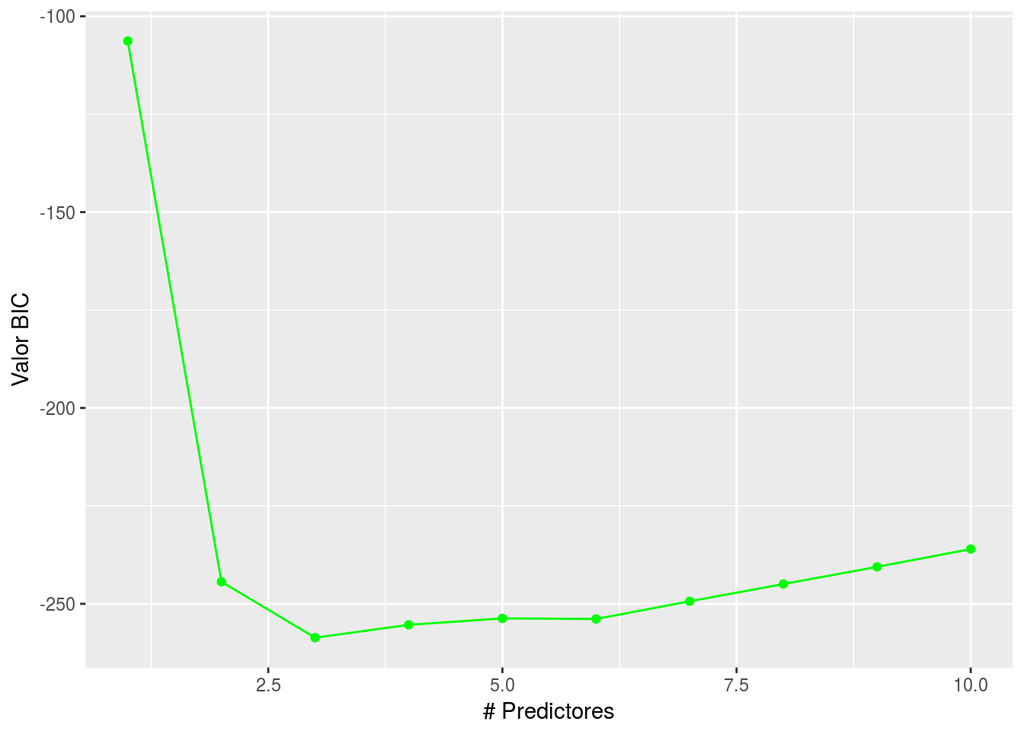

```r
p <- ggplot(data = data.frame(n_predictores = 1:10,
                              bic_ex = summ_ex$bic[1:10]),
            aes(x = n_predictores, y = bic_ex)) +
  geom_line(color="green") +
  geom_point(color="green")+
  xlab("# Predictores")+
  ylab("Valor BIC")
p
```

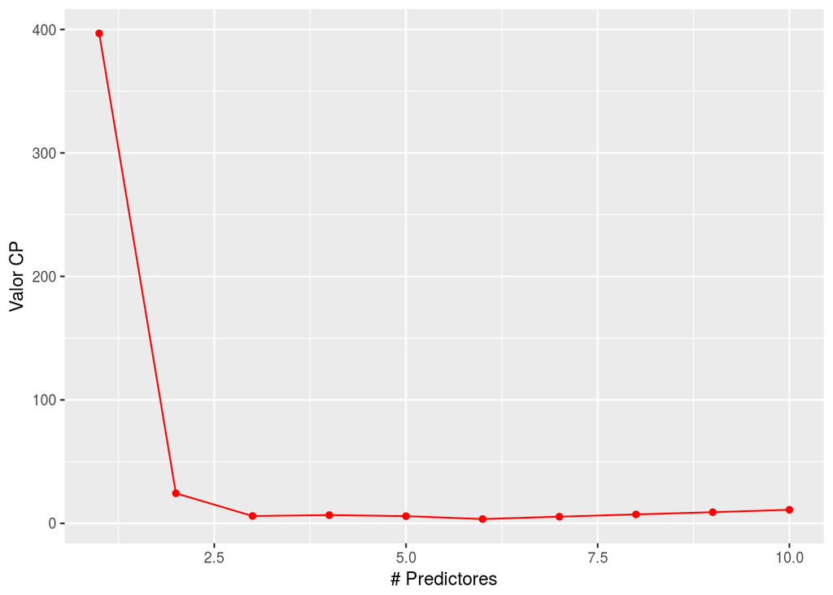

```r
p <- ggplot(data = data.frame(n_predictores = 1:10,
                              cp_ex = summ_ex$cp[1:10]),
            aes(x = n_predictores, y = cp_ex)) +
  geom_line(color="red") +
  geom_point(color="red")+
  xlab("# Predictores")+
  ylab("Valor CP")
p
```

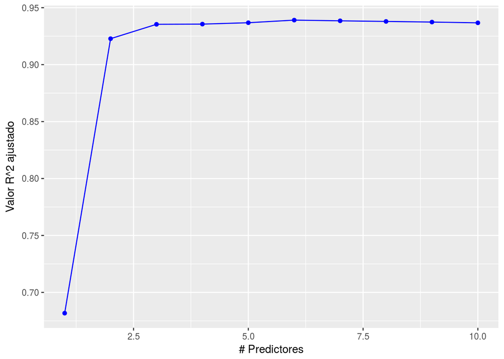

```r
p <- ggplot(data = data.frame(n_predictores = 1:10,
                              adjr2_ex = summ_ex$adjr2[1:10]),
            aes(x = n_predictores, y = adjr2_ex)) +
  geom_line(color="blue") +
  geom_point(color="blue")+
  xlab("# Predictores")+
  ylab("Valor R^2 ajustado")
p
```

```r
#Matriz de modelos seleccionados por # de variables
#summ_ex$which
knitr::kable(summ_ex$which,format = "latex")
```

```r
# Mejores modelos
best_ex_adjr2<-which.max(summ_ex$adjr2)
best_ex_bic<-which.min(summ_ex$bic)
best_ex_cp<-which.min(summ_ex$cp)

#Encontarar coeficientes de los modelos
coef_ex_adjr2<-coef(mejores_modelos_ex,best_ex_adjr2)
coef_ex_bic<-coef(mejores_modelos_ex,best_ex_bic)
coef_ex_cp<-coef(mejores_modelos_ex,best_ex_cp)



# p <- ggplot(data = data.frame(n_predictores = 2:10,
#                               adjr2_fw = summ_fw$adjr2[2:10]),
#             aes(x = n_predictores, y = adjr2_fw)) +
#   geom_line() +
#   geom_point()
# p


####(d) Ahora con forward backawrd step####

 mejores_modelos_fw<-regsubsets(Y~.,data =Xmat_df,nvmax = 10,method =  "forward")
 #summary(mejores_modelos_fw)
 summ_fw<- summary(mejores_modelos_fw)
 #summ_fw$adjr2
 #summ_fw$cp
 #summ_fw$bic
 knitr::kable(data.frame(fw_adjr2=summ_fw$adjr2,fw_cp=summ_fw$cp,fw_bic=summ_fw$bic),format = "latex" )
```

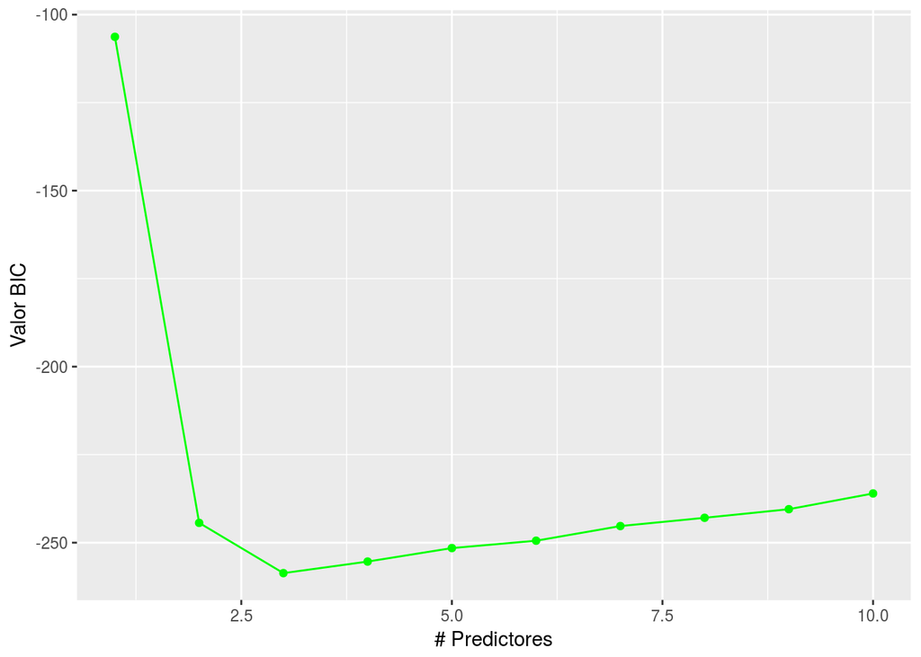

```r
 p <- ggplot(data = data.frame(n_predictores = 1:10,
                               bic_fw = summ_fw$bic[1:10]),
             aes(x = n_predictores, y = bic_fw)) +
   geom_line(color="green") +
   geom_point(color="green")+
   xlab("# Predictores")+
   ylab("Valor BIC")
 p
```

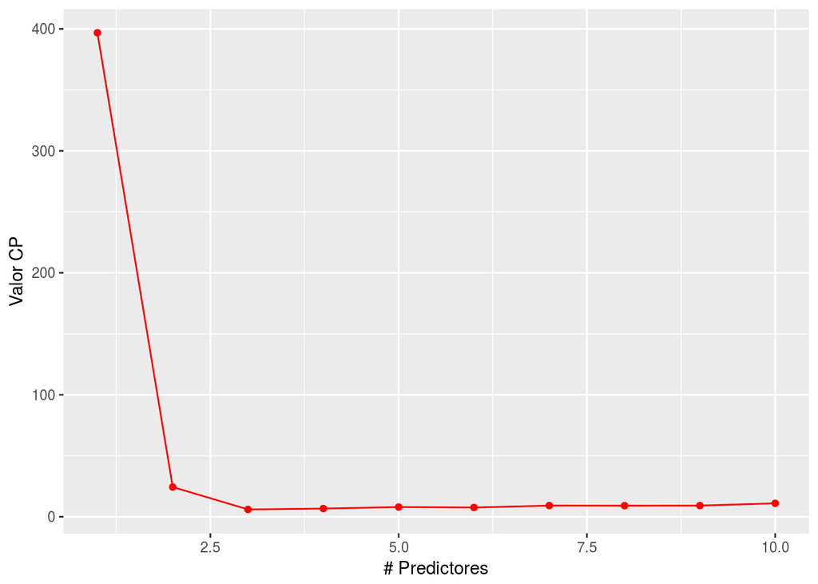

```r
 p <- ggplot(data = data.frame(n_predictores = 1:10,
                               cp_fw = summ_fw$cp[1:10]),
             aes(x = n_predictores, y = cp_fw)) +
   geom_line(color="red") +
   geom_point(color="red")+
   xlab("# Predictores")+
   ylab("Valor CP")
 p
```

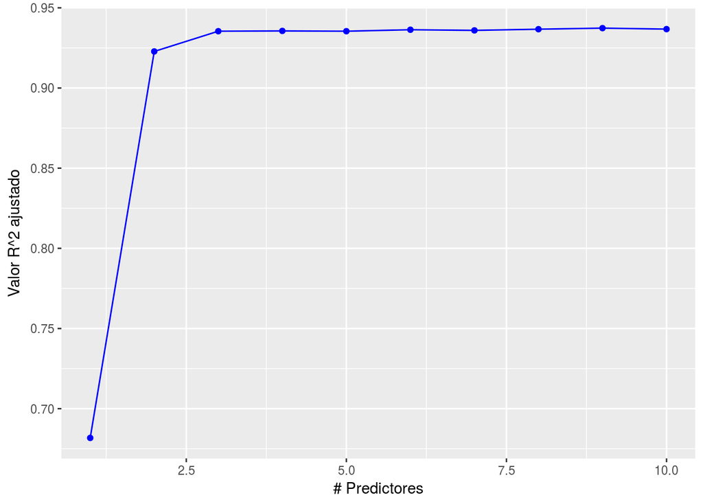

```r
 p <- ggplot(data = data.frame(n_predictores = 1:10,
                               adjr2_fw = summ_fw$adjr2[1:10]),
             aes(x = n_predictores, y = adjr2_fw)) +
   geom_line(color="blue") +
   geom_point(color="blue")+
   xlab("# Predictores")+
   ylab("Valor R^2 ajustado")
 p
```

```r
 #Matriz de modelos seleccionados por # de variables
 #summ_fw$which
 knitr::kable(summ_fw$which,format = "latex")
```

```r
 # Mejores modelos
 best_fw_adjr2<-which.max(summ_fw$adjr2)
 best_fw_bic<-which.min(summ_fw$bic)
 best_fw_cp<-which.min(summ_fw$cp)

 #Encontarar coeficientes de los modelos
 coef_fw_adjr2<-coef(mejores_modelos_fw,best_fw_adjr2)
 coef_fw_bic<-coef(mejores_modelos_fw,best_fw_bic)
 coef_fw_cp<-coef(mejores_modelos_fw,best_fw_cp)

 #### BACKWARD ####

 mejores_modelos_bw<-regsubsets(Y~.,data =Xmat_df,nvmax = 10,method =  "backward")
 #summary(mejores_modelos_bw)
 summ_bw<- summary(mejores_modelos_bw)
 # summ_bw$adjr2
 # summ_bw$cp
 # summ_bw$bic
 knitr::kable(data.frame(bw_adjr2=summ_bw$adjr2,bw_cp=summ_bw$cp,bw_bic=summ_bw$bic),format = "latex" )
```

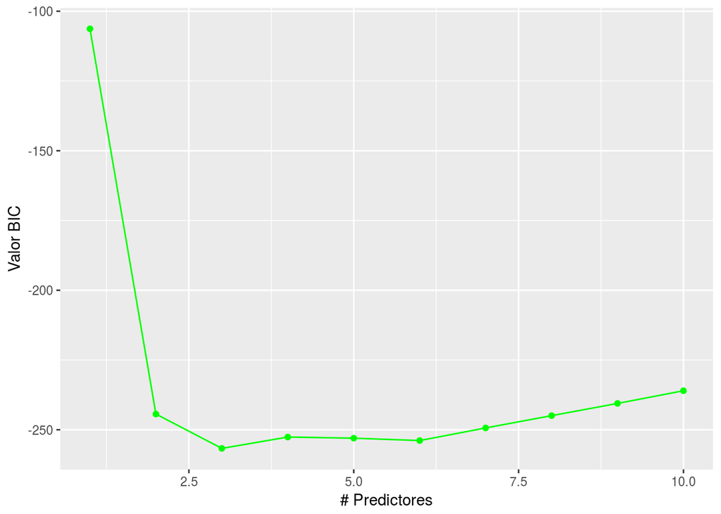

```r
 p <- ggplot(data = data.frame(n_predictores = 1:10,
                               bic_bw = summ_bw$bic[1:10]),
             aes(x = n_predictores, y = bic_bw)) +
   geom_line(color="green") +
   geom_point(color="green")+
   xlab("# Predictores")+
   ylab("Valor BIC")
 p
```

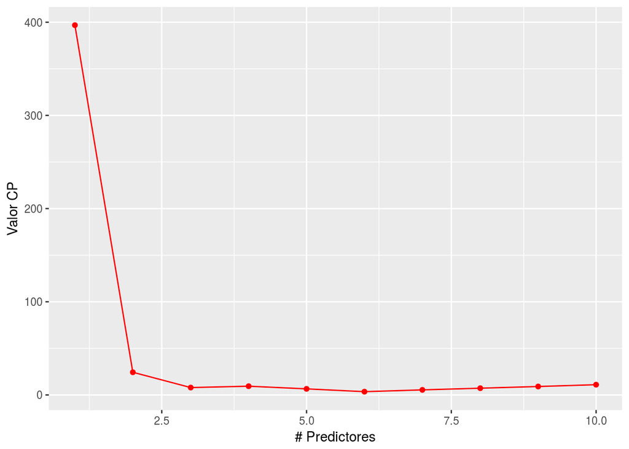

```r
 p <- ggplot(data = data.frame(n_predictores = 1:10,
                               cp_bw = summ_bw$cp[1:10]),
             aes(x = n_predictores, y = cp_bw)) +
   geom_line(color="red") +
   geom_point(color="red")+
   xlab("# Predictores")+
   ylab("Valor CP")
 p
```

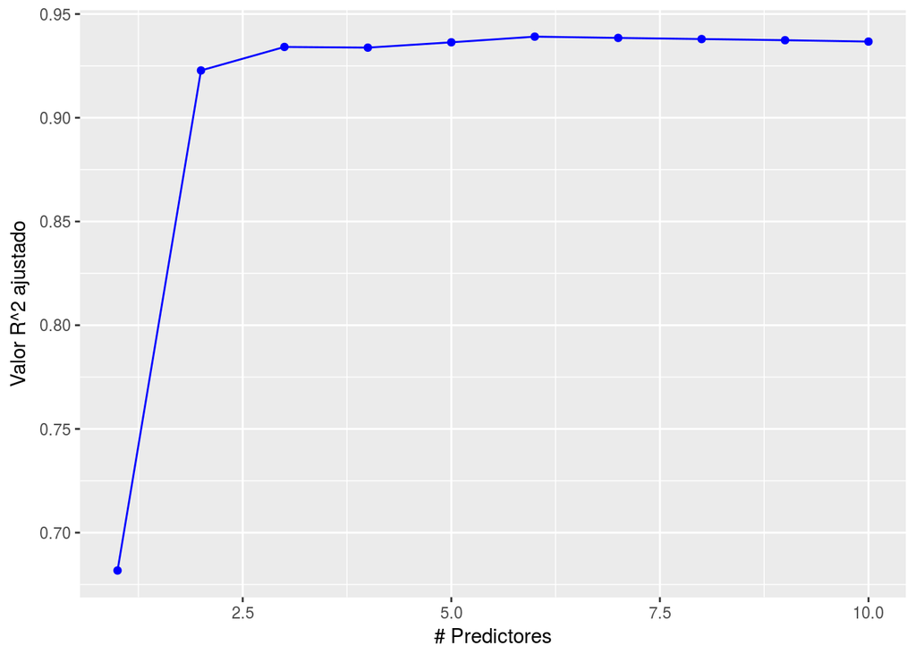

```r
 p <- ggplot(data = data.frame(n_predictores = 1:10,
                               adjr2_bw = summ_bw$adjr2[1:10]),
             aes(x = n_predictores, y = adjr2_bw)) +
   geom_line(color="blue") +
   geom_point(color="blue")+
   xlab("# Predictores")+
   ylab("Valor R^2 ajustado")
 p
```

```r
 #Matriz de modelos seleccionados por # de variables
 knitr::kable(summ_bw$which,format = "latex")
```

[figure not shown]

```r
 # Mejores modelos
 best_bw_adjr2<-which.max(summ_bw$adjr2)
 best_bw_bic<-which.min(summ_bw$bic)
 best_bw_cp<-which.min(summ_bw$cp)

 #Encontarar coeficientes de los modelos
 coef_bw_adjr2<-coef(mejores_modelos_bw,best_bw_adjr2)
 coef_bw_bic<-coef(mejores_modelos_bw,best_bw_bic)
 coef_bw_cp<-coef(mejores_modelos_bw,best_bw_cp)

 #------------------------------------------------------------
 p <- ggplot(data = data.frame(n_predictores = 1:10,
                               adjr2_bw = summ_bw$adjr2[1:10],
                               cp_bw = summ_bw$cp[1:10],
                               bic_bw = summ_bw$bic[1:10])) +
   geom_line(aes(x = n_predictores, y = adjr2_bw,color="green")) +
   xlab("# Predictores")+
   ylab("Valor Metrica")+
   geom_point(aes(x = n_predictores, y = adjr2_bw,color="green"))+
   geom_line(aes(x = n_predictores, y = cp_bw,color="red")) +
   geom_point(aes(x = n_predictores, y = cp_bw,color="red"))+
   geom_line(aes(x = n_predictores, y = bic_bw,color="blue")) +
   geom_point(aes(x = n_predictores, y = bic_bw,color="blue"))+
   scale_color_discrete(name = "Accuracy Metrics", labels = c("CP", "adj_r2","BIC"))
 p
```

```r
 #When picking from several models, the one with the lowest BIC is preferred.
 # The highest adj_r2 is preferred
 # the lowest CP is preferred

###https://rpubs.com/Joaquin_AR/242707 (Usar regsubsets y graficas de regsubsets)
 #http://jadianes.me/best-subset-model-selection-with-R
```